# Working with the Volume Data

Exploratory Data Analysis for Volume Data

Alexis Solis Cancino alexis.solisc@gmail.com (ITAM)  
2020-09-29

## Exploratory Data Analysis for the Volume Data

By doing a quick inspection, we see that there are:

```
[1] 269189
```

… `269,189` zero-values in the data, so we’ll filter those out.

First, let’s plot the volume on two random days:

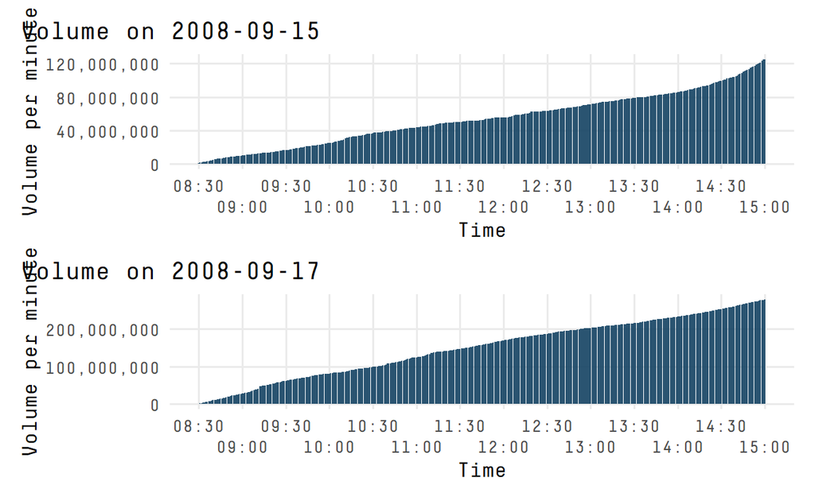

We see that we have the **cumulative volume** in the data. If we take the difference between each data point, we’ll have the correct data. Let’s plot it:

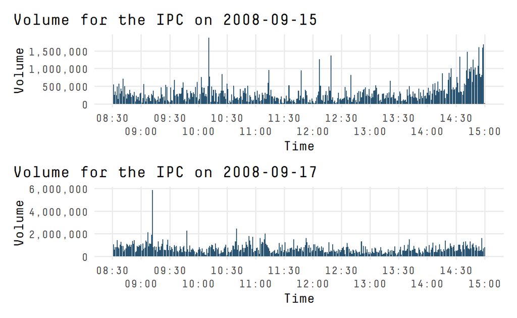

… which looks correct.

Now, this situation begs the question: will this transformation work for **all days** in the dataset? Let’s try another day:

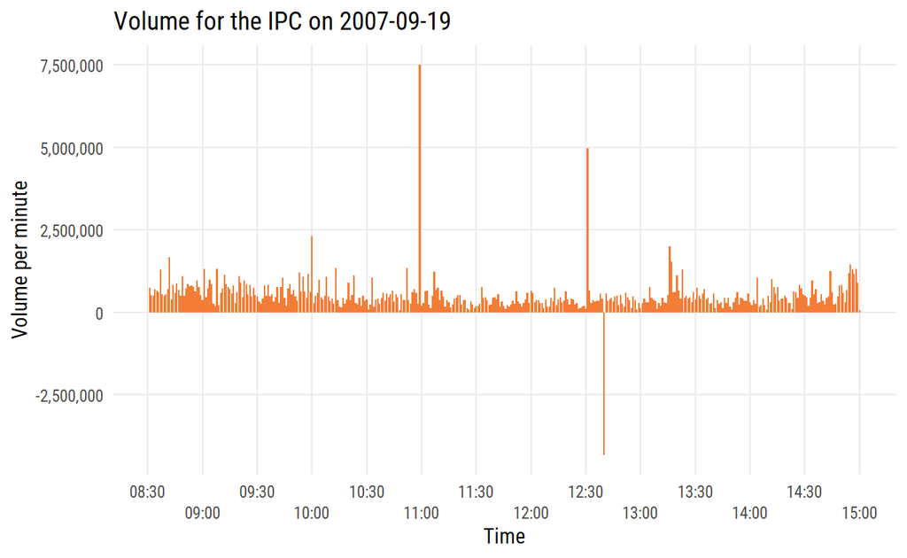

Here, we tried Wednesday September 19, 2007; and the large and negative value that was computed for this day would indicate that this doesn’t work for every day. First, let’s analyze what happened there. We see that the negative value was computed between 12:00 and 13:00. First, let’s see what was the exact time:

```
12:40:00
```

So 12:40, let’s now filter the data around that time:

| Volume | Cumulative Volume | Time |
| --- | --- | --- |
| 312,900 | 136,641,675 | 12:35 PM |
| 342,358 | 136,984,033 | 12:36 PM |
| 342,900 | 137,326,933 | 12:37 PM |
| 555,100 | 137,882,033 | 12:38 PM |
| 413,200 | 138,295,233 | 12:39 PM |
| −4,325,900 | 133,969,333 | 12:40 PM |
| 562,620 | 134,531,953 | 12:41 PM |
| 336,800 | 134,868,753 | 12:42 PM |
| 375,900 | 135,244,653 | 12:43 PM |
| 428,300 | 135,672,953 | 12:44 PM |
| 315,200 | 135,988,153 | 12:45 PM |

So, we see the cumulative volume gets to 138,295,233 before it decreases to 133,969,333. It’s not clear what causes the cumulative volume to decrease at 12:40PM, but for now, we’ll just filter the negative values for volume. The `new_volume` variable is calculated as the difference between the current (cumulative) volume and its previous value. We do this except for the points where the days change, so no “overnight” calculation is done.

Let’s see some summary statistics on the volume data:

Volume Data Summary Statistics

| Measure | Value |
| --- | --- |
| Min | 1 |
| Median | 232,615 |
| Mean | 362,777 |
| Max | 1,200,266,388 |
| Standard Dev | 1,744,727 |

We can create a histogram for the volume data. In this case we’ve plotted the histogram for the natural log of the `new_volume` variable.

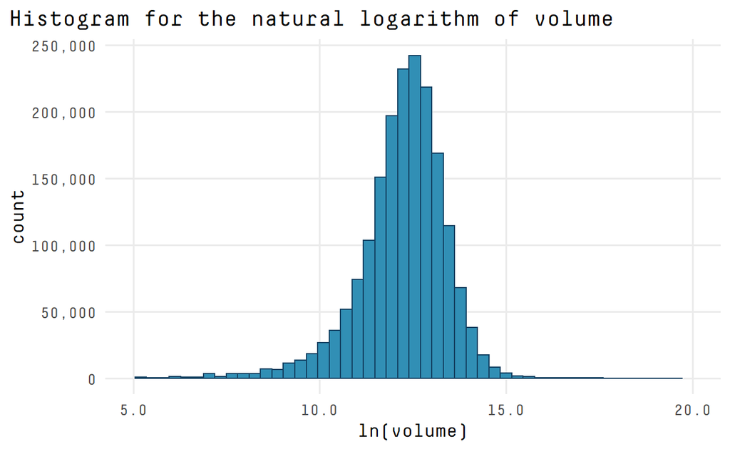

Now, we proceed to do the same plot, but separating by year:

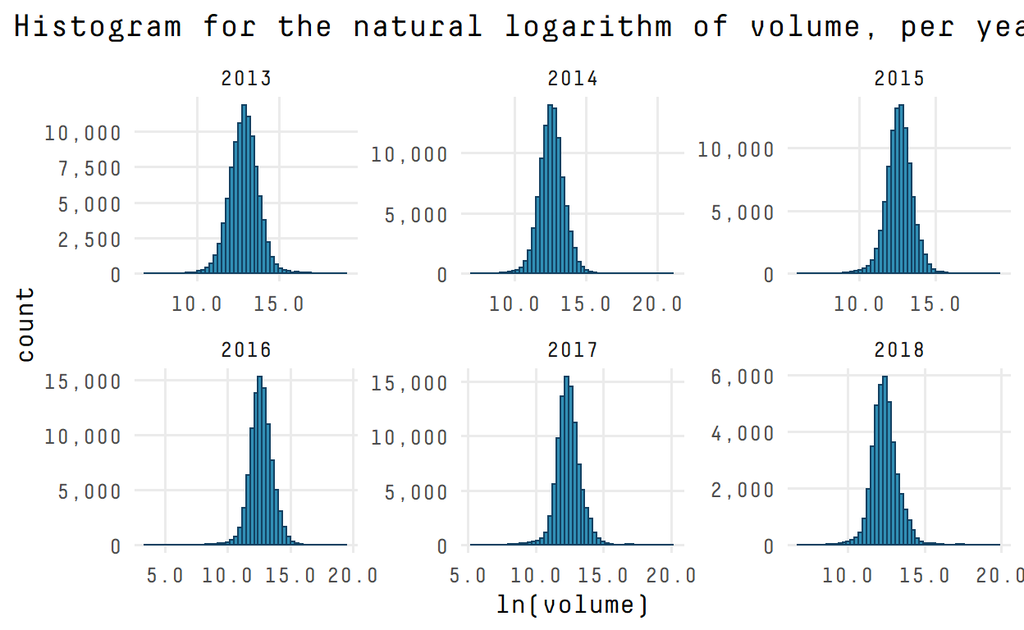

## Time Series for time subgrids.

We plot this down below. Here, we can see that the most active half-hours are the last and first ones.

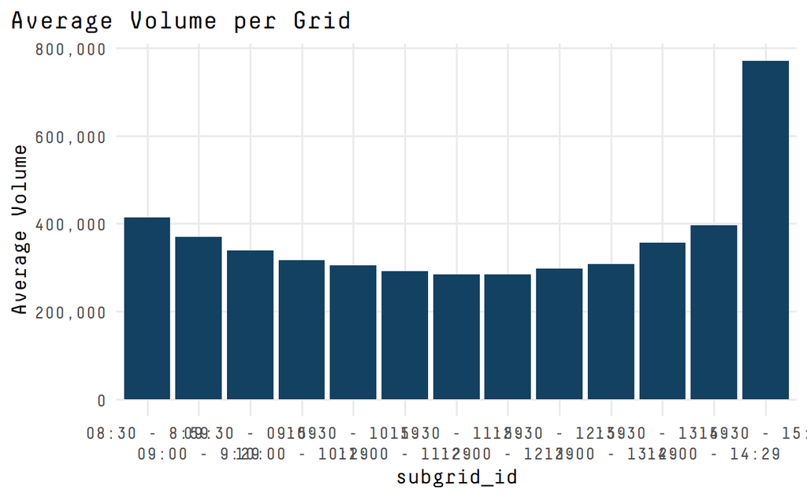

## Volume by week and by weekday

Next, we can go ahead and do a similar analysis, but by week. To see which weeks in the year are the most active.

In the plot below we can see that the weeks 12, 11, and 13 are one of the most active (the 44th week gets on third place). Unsuprisingly, the last week of the year is the least active, probably due to holidays.

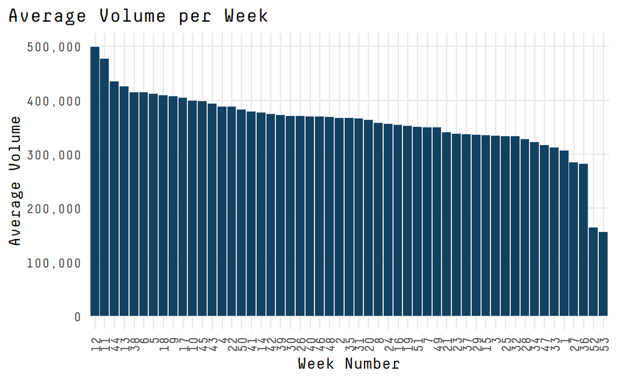

Finally, we do the analysis by day of the week. Interestingly, the most active weekday is Wednesday (with an average volume of 391,737), followed by Thursday (380,367) and Tuesday (378,052). Mondays are notably less active.

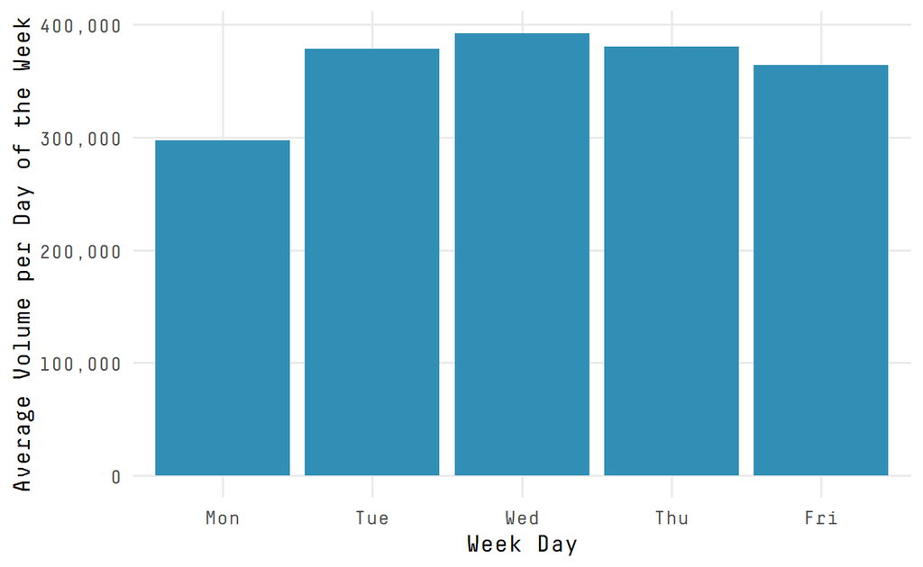